# Modul 2: Desain Eksperimen Faktorial dan ANOVA Dua Arah

Immantaka Juniarsa

05 November 2026

```r
suppressPackageStartupMessages({ library(dplyr); library(tidyr); library(ggplot2); library(car) })
source("R/plot_theme.R")
pastikan_utf8()   # simbol ° dan × pada grafik tergambar benar di lokal apa pun
exp_df <- read.csv("data/raw/eksperimen_faktorial.csv") %>%
  mutate(temperature = factor(temperature, levels = c(150, 175, 200),
                              labels = c("150°C", "175°C", "200°C")),
         material    = factor(material, levels = c("A", "B"),
                              labels = c("Bahan A", "Bahan B")))
```

## 1. Latar belakang dan rancangan

Sebuah proses perlakuan panas ingin diketahui pengaruh **suhu** (150, 175, 200 °C) dan **jenis bahan** (A, B) terhadap **kekuatan tarik** (MPa). Rancangan: **faktorial penuh 3 × 2 dengan 5 replikasi** (30 run), urutan run diacak sepenuhnya (*completely randomized design*). Pertanyaan:

1. Apakah suhu dan bahan berpengaruh pada kekuatan tarik?
2. Apakah efek suhu **bergantung** pada jenis bahan (interaksi)?
3. Kombinasi mana yang memberi kekuatan tertinggi, dan seberapa besar efeknya secara praktis?

> Data disimulasikan (`simulate_experiment()`, `set.seed(2024)`) dengan interaksi yang sengaja ditanam: keunggulan Bahan B mengecil pada suhu tinggi.

### 1.1 Tabel rancangan

```r
knitr::kable(exp_df %>% count(temperature, material) %>%
               pivot_wider(names_from = material, values_from = n),
             caption = "Jumlah replikasi per sel (rancangan seimbang)")
```

Jumlah replikasi per sel (rancangan seimbang)

| temperature | Bahan A | Bahan B |
| --- | --- | --- |
| 150°C | 5 | 5 |
| 175°C | 5 | 5 |
| 200°C | 5 | 5 |

```r
knitr::kable(head(exp_df, 10), caption = "Sepuluh run pertama sesuai urutan acak")
```

Sepuluh run pertama sesuai urutan acak

| run_order | temperature | material | replicate | tensile_strength |
| --- | --- | --- | --- | --- |
| 1 | 150°C | Bahan B | 2 | 48.18 |
| 2 | 175°C | Bahan B | 1 | 49.67 |
| 3 | 150°C | Bahan A | 5 | 42.55 |
| 4 | 200°C | Bahan B | 5 | 48.76 |
| 5 | 175°C | Bahan A | 5 | 38.80 |
| 6 | 150°C | Bahan B | 3 | 46.72 |
| 7 | 200°C | Bahan B | 3 | 50.51 |
| 8 | 200°C | Bahan A | 4 | 47.53 |
| 9 | 150°C | Bahan B | 5 | 44.53 |
| 10 | 175°C | Bahan B | 2 | 47.95 |

## 2. Eksplorasi data

```r
cell_stats <- exp_df %>% group_by(temperature, material) %>%
  summarise(n = n(), mean = mean(tensile_strength), sd = sd(tensile_strength),
            min = min(tensile_strength), max = max(tensile_strength), .groups = "drop") %>%
  mutate(across(c(mean, sd), ~ round(.x, 2)))
knitr::kable(cell_stats, caption = "Statistik deskriptif per sel")
```

Statistik deskriptif per sel

| temperature | material | n | mean | sd | min | max |
| --- | --- | --- | --- | --- | --- | --- |
| 150°C | Bahan A | 5 | 41.01 | 1.36 | 39.53 | 42.55 |
| 150°C | Bahan B | 5 | 46.72 | 2.37 | 44.31 | 49.84 |
| 175°C | Bahan A | 5 | 44.52 | 3.85 | 38.80 | 47.83 |
| 175°C | Bahan B | 5 | 48.13 | 2.23 | 45.57 | 51.00 |
| 200°C | Bahan A | 5 | 49.18 | 1.23 | 47.53 | 50.51 |
| 200°C | Bahan B | 5 | 47.62 | 2.49 | 44.48 | 50.51 |

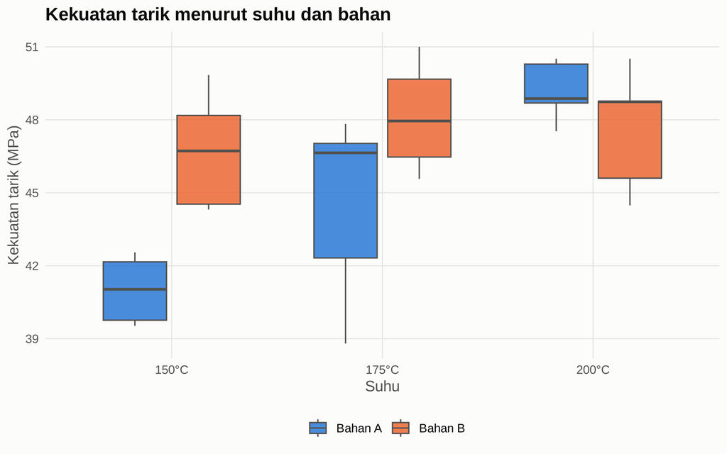

Sebaran kekuatan tarik per kombinasi perlakuan

```r
pal2 <- pal_kategori()[1:2]
p_box <- ggplot(exp_df, aes(temperature, tensile_strength, fill = material)) +
  geom_boxplot(alpha = 0.85, width = 0.6, position = position_dodge(0.7),
               outlier.shape = 21, colour = "#52514e") +
  scale_fill_manual(values = pal2, name = NULL) +
  labs(title = "Kekuatan tarik menurut suhu dan bahan", x = "Suhu", y = "Kekuatan tarik (MPa)") +
  theme_portofolio()
p_box
```

```r
simpan_grafik(p_box, "02_boxplot_perlakuan")
```

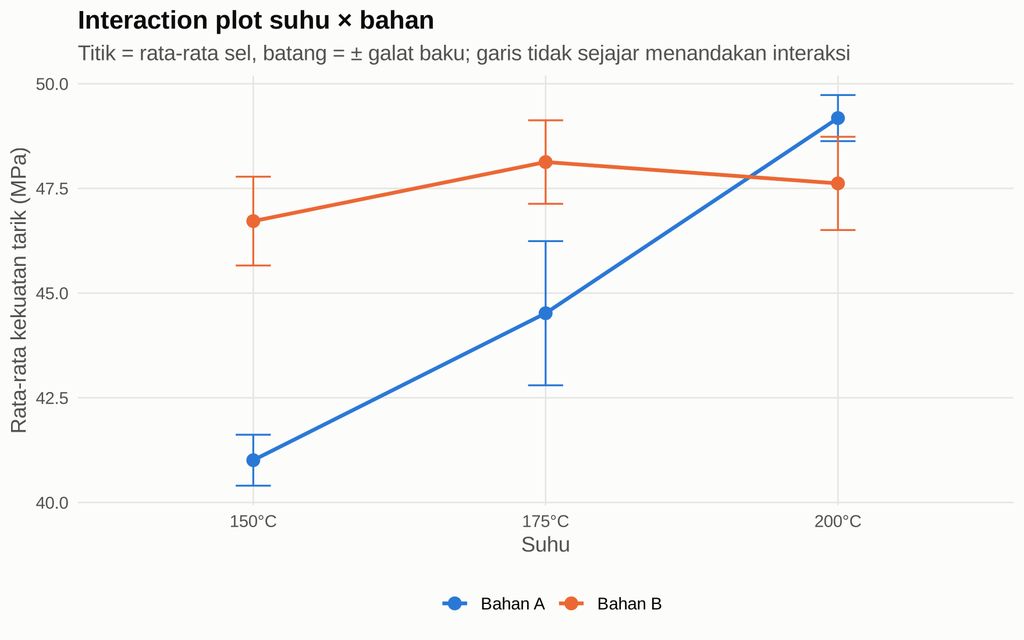

Interaction plot: rata-rata sel

```r
p_int <- ggplot(cell_stats, aes(temperature, mean, colour = material, group = material)) +
  geom_line(linewidth = 1) +
  geom_point(size = 3) +
  geom_errorbar(aes(ymin = mean - sd / sqrt(n), ymax = mean + sd / sqrt(n)), width = 0.12) +
  scale_colour_manual(values = pal2, name = NULL) +
  labs(title = "Interaction plot suhu × bahan",
       subtitle = "Titik = rata-rata sel, batang = ± galat baku; garis tidak sejajar menandakan interaksi",
       x = "Suhu", y = "Rata-rata kekuatan tarik (MPa)") +
  theme_portofolio()
p_int
```

```r
simpan_grafik(p_int, "02_interaction_plot")
```

Garis Bahan A dan B **tidak sejajar**: selisih A–B besar pada 150 °C dan hampir hilang pada 200 °C. Ini indikasi visual interaksi yang akan diuji secara formal.

## 3. ANOVA dua arah dengan interaksi

Model: $y_{ijk} = \mu + \tau_i + \beta_j + (\tau\beta)_{ij} + \varepsilon_{ijk}$, dengan $\varepsilon \sim N(0, \sigma^2)$. Karena rancangan seimbang, jumlah kuadrat Tipe I, II, dan III identik; ditampilkan Tipe II dari `car::Anova` sebagai pembanding `anova()` bawaan.

```r
fit <- lm(tensile_strength ~ temperature * material, data = exp_df)
anova_tbl <- anova(fit)
knitr::kable(round(anova_tbl, 4), caption = "Tabel ANOVA (jumlah kuadrat sekuensial / Tipe I)")
```

Tabel ANOVA (jumlah kuadrat sekuensial / Tipe I)

|  | Df | Sum Sq | Mean Sq | F value | Pr(>F) |
| --- | --- | --- | --- | --- | --- |
| temperature | 2 | 103.1845 | 51.5923 | 8.8392 | 0.0013 |
| material | 1 | 50.1555 | 50.1555 | 8.5930 | 0.0073 |
| temperature:material | 2 | 69.9829 | 34.9915 | 5.9950 | 0.0077 |
| Residuals | 24 | 140.0822 | 5.8368 | NA | NA |

```r
anova2 <- car::Anova(fit, type = 2)
stopifnot(all(abs(anova2$`Sum Sq` - anova_tbl$`Sum Sq`) < 1e-8))  # identik pada desain seimbang
p_temp <- anova_tbl["temperature", "Pr(>F)"]
p_mat  <- anova_tbl["material", "Pr(>F)"]
p_int  <- anova_tbl["temperature:material", "Pr(>F)"]
fmt_p  <- function(p) ifelse(p < 0.001, "< 0,001", paste("=", signif(p, 3)))
```

| Sumber | F | p-value | Keputusan (α = 5%) |
| --- | --- | --- | --- |
| Suhu | 8.84 | = 0.00133 | Signifikan |
| Bahan | 8.59 | = 0.0073 | Signifikan |
| Suhu × Bahan | 6 | = 0.00773 | Signifikan |

R² model = 0.615; R² terkoreksi = 0.534.

### 3.1 Ukuran efek (eta-squared parsial)

$\eta^2_p = SS_{efek} / (SS_{efek} + SS_{galat})$. Acuan Cohen: 0,01 kecil, 0,06 sedang, 0,14 besar.

```r
ss_err <- anova_tbl["Residuals", "Sum Sq"]
eta_tbl <- data.frame(
  efek = rownames(anova_tbl)[1:3],
  SS   = anova_tbl$`Sum Sq`[1:3]
) %>% mutate(eta_sq_partial = SS / (SS + ss_err),
             eta_sq         = SS / sum(anova_tbl$`Sum Sq`),
             kategori = cut(eta_sq_partial, c(-Inf, 0.01, 0.06, 0.14, Inf),
                            labels = c("Dapat diabaikan", "Kecil", "Sedang", "Besar")))
knitr::kable(eta_tbl %>% mutate(across(where(is.numeric), ~ round(.x, 3))),
             caption = "Eta-squared parsial dan eta-squared klasik")
```

Eta-squared parsial dan eta-squared klasik

| efek | SS | eta_sq_partial | eta_sq | kategori |
| --- | --- | --- | --- | --- |
| temperature | 103.185 | 0.424 | 0.284 | Besar |
| material | 50.155 | 0.264 | 0.138 | Besar |
| temperature:material | 69.983 | 0.333 | 0.193 | Besar |

## 4. Pemeriksaan asumsi

```r
res <- residuals(fit)
sw  <- shapiro.test(res)
lev <- car::leveneTest(tensile_strength ~ temperature * material, data = exp_df)
```

| Asumsi | Uji | Statistik | p-value | Kesimpulan |
| --- | --- | --- | --- | --- |
| Normalitas residual | Shapiro-Wilk | W = 0.9541 | = 0.217 | Normalitas tidak ditolak |
| Homogenitas varians | Levene (median) | F = 0.701 | = 0.628 | Varians homogen |

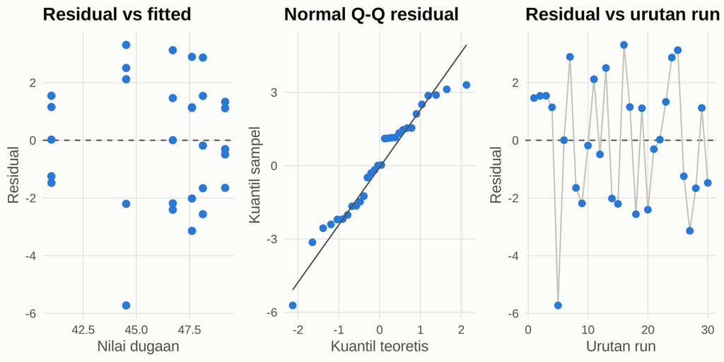

Diagnostik residual

```r
diag_df <- data.frame(fitted = fitted(fit), res = res, run = exp_df$run_order)
p1 <- ggplot(diag_df, aes(fitted, res)) +
  geom_hline(yintercept = 0, colour = "#52514e", linetype = "dashed") +
  geom_point(colour = pal_kategori()[1], size = 2.4) +
  labs(title = "Residual vs fitted", x = "Nilai dugaan", y = "Residual") + theme_portofolio()
p2 <- ggplot(diag_df, aes(sample = res)) +
  stat_qq(colour = pal_kategori()[1], size = 2.2) + stat_qq_line(colour = "#52514e") +
  labs(title = "Normal Q-Q residual", x = "Kuantil teoretis", y = "Kuantil sampel") + theme_portofolio()
p3 <- ggplot(diag_df, aes(run, res)) +
  geom_hline(yintercept = 0, colour = "#52514e", linetype = "dashed") +
  geom_line(colour = "#c3c2b7") + geom_point(colour = pal_kategori()[1], size = 2.2) +
  labs(title = "Residual vs urutan run", x = "Urutan run", y = "Residual") + theme_portofolio()
grid::grid.newpage()
grid::pushViewport(grid::viewport(layout = grid::grid.layout(1, 3)))
print(p1, vp = grid::viewport(layout.pos.row = 1, layout.pos.col = 1))
print(p2, vp = grid::viewport(layout.pos.row = 1, layout.pos.col = 2))
print(p3, vp = grid::viewport(layout.pos.row = 1, layout.pos.col = 3))
```

Tidak terlihat pola corong (varians konstan) maupun tren terhadap urutan run (independensi terjaga berkat pengacakan).

## 5. Uji lanjut Tukey HSD

Karena interaksi signifikan, perbandingan dilakukan pada level kombinasi (sel), bukan hanya efek utama.

```r
aov_fit <- aov(tensile_strength ~ temperature * material, data = exp_df)
tk_temp <- TukeyHSD(aov_fit, "temperature")
tk_int  <- TukeyHSD(aov_fit, "temperature:material")
knitr::kable(round(tk_temp$temperature, 3), caption = "Tukey HSD efek utama suhu")
```

Tukey HSD efek utama suhu

|  | diff | lwr | upr | p adj |
| --- | --- | --- | --- | --- |
| 175°C-150°C | 2.467 | -0.231 | 5.165 | 0.078 |
| 200°C-150°C | 4.537 | 1.839 | 7.235 | 0.001 |
| 200°C-175°C | 2.070 | -0.628 | 4.768 | 0.156 |

```r
tk_int_df <- as.data.frame(tk_int$`temperature:material`) %>%
  mutate(perbandingan = rownames(.), .before = 1) %>%
  arrange(`p adj`) %>% mutate(across(where(is.numeric), ~ round(.x, 3)))
knitr::kable(tk_int_df, caption = "Tukey HSD semua pasangan sel (diurutkan menurut p terkoreksi)")
```

Tukey HSD semua pasangan sel (diurutkan menurut p terkoreksi)

|  | perbandingan | diff | lwr | upr | p adj |
| --- | --- | --- | --- | --- | --- |
| 200°C:Bahan A-150°C:Bahan A | 200°C:Bahan A-150°C:Bahan A | 8.172 | 3.448 | 12.896 | 0.000 |
| 175°C:Bahan B-150°C:Bahan A | 175°C:Bahan B-150°C:Bahan A | 7.126 | 2.402 | 11.850 | 0.001 |
| 200°C:Bahan B-150°C:Bahan A | 200°C:Bahan B-150°C:Bahan A | 6.612 | 1.888 | 11.336 | 0.003 |
| 150°C:Bahan B-150°C:Bahan A | 150°C:Bahan B-150°C:Bahan A | 5.710 | 0.986 | 10.434 | 0.012 |
| 200°C:Bahan A-175°C:Bahan A | 200°C:Bahan A-175°C:Bahan A | 4.654 | -0.070 | 9.378 | 0.055 |
| 175°C:Bahan B-175°C:Bahan A | 175°C:Bahan B-175°C:Bahan A | 3.608 | -1.116 | 8.332 | 0.210 |
| 175°C:Bahan A-150°C:Bahan A | 175°C:Bahan A-150°C:Bahan A | 3.518 | -1.206 | 8.242 | 0.232 |
| 200°C:Bahan B-175°C:Bahan A | 200°C:Bahan B-175°C:Bahan A | 3.094 | -1.630 | 7.818 | 0.358 |
| 150°C:Bahan B-200°C:Bahan A | 150°C:Bahan B-200°C:Bahan A | -2.462 | -7.186 | 2.262 | 0.599 |
| 150°C:Bahan B-175°C:Bahan A | 150°C:Bahan B-175°C:Bahan A | 2.192 | -2.532 | 6.916 | 0.707 |
| 200°C:Bahan B-200°C:Bahan A | 200°C:Bahan B-200°C:Bahan A | -1.560 | -6.284 | 3.164 | 0.906 |
| 175°C:Bahan B-150°C:Bahan B | 175°C:Bahan B-150°C:Bahan B | 1.416 | -3.308 | 6.140 | 0.936 |
| 175°C:Bahan B-200°C:Bahan A | 175°C:Bahan B-200°C:Bahan A | -1.046 | -5.770 | 3.678 | 0.982 |
| 200°C:Bahan B-150°C:Bahan B | 200°C:Bahan B-150°C:Bahan B | 0.902 | -3.822 | 5.626 | 0.991 |
| 200°C:Bahan B-175°C:Bahan B | 200°C:Bahan B-175°C:Bahan B | -0.514 | -5.238 | 4.210 | 0.999 |

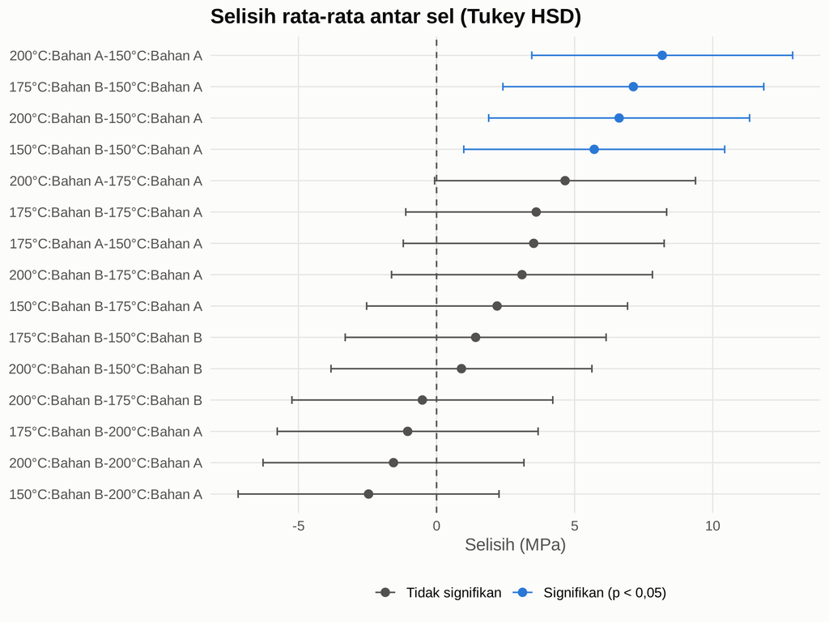

Interval kepercayaan Tukey 95% untuk pasangan sel

```r
ggplot(tk_int_df, aes(x = diff, y = reorder(perbandingan, diff))) +
  geom_vline(xintercept = 0, linetype = "dashed", colour = "#52514e") +
  geom_errorbarh(aes(xmin = lwr, xmax = upr,
                     colour = `p adj` < 0.05), height = 0.25) +
  geom_point(aes(colour = `p adj` < 0.05), size = 2.4) +
  scale_colour_manual(values = c(`FALSE` = "#52514e", `TRUE` = pal_kategori()[1]),
                      labels = c("Tidak signifikan", "Signifikan (p < 0,05)"), name = NULL) +
  labs(title = "Selisih rata-rata antar sel (Tukey HSD)", x = "Selisih (MPa)", y = NULL) +
  theme_portofolio()
```

### 5.1 Perbandingan Bahan A vs B pada tiap suhu (slicing interaksi)

```r
slice_tbl <- tk_int_df %>%
  filter(grepl("^(150°C|175°C|200°C):Bahan B-\\1:Bahan A$", perbandingan)) %>%
  mutate(suhu = sub(":.*", "", perbandingan)) %>%
  dplyr::select(suhu, diff, lwr, upr, `p adj`)
knitr::kable(slice_tbl, caption = "Selisih Bahan B − Bahan A pada tiap suhu")
```

Selisih Bahan B − Bahan A pada tiap suhu

|  | suhu | diff | lwr | upr | p adj |
| --- | --- | --- | --- | --- | --- |
| 150°C:Bahan B-150°C:Bahan A | 150°C | 5.710 | 0.986 | 10.434 | 0.012 |
| 175°C:Bahan B-175°C:Bahan A | 175°C | 3.608 | -1.116 | 8.332 | 0.210 |
| 200°C:Bahan B-200°C:Bahan A | 200°C | -1.560 | -6.284 | 3.164 | 0.906 |

## 6. Pembanding non-parametrik: Kruskal-Wallis

Bila asumsi normalitas diragukan (misal ukuran sampel kecil atau ada pencilan), uji Kruskal-Wallis dapat dipakai untuk efek suhu dan Mann-Whitney (Wilcoxon rank-sum) untuk bahan. Perhatikan bahwa uji ini tidak memodelkan interaksi.

```r
kw <- kruskal.test(tensile_strength ~ temperature, data = exp_df)
mw <- wilcox.test(tensile_strength ~ material, data = exp_df, exact = FALSE)
```

| Uji | Statistik | p-value | Padanan parametrik |
| --- | --- | --- | --- |
| Kruskal-Wallis (suhu) | H = 8.102, df = 2 | = 0.0174 | ANOVA efek suhu, p = 0.00133 |
| Wilcoxon rank-sum (bahan) | W = 73.5 | = 0.11 | ANOVA efek bahan, p = 0.0073 |

Untuk **suhu**, kesimpulan konsisten. Untuk **bahan**, uji Wilcoxon tidak signifikan sedangkan ANOVA signifikan. Perbedaan ini wajar: Wilcoxon membandingkan dua kelompok bahan dengan mengabaikan suhu, sehingga variasi akibat suhu dan interaksi masuk ke dalam ‘galat’ dan menurunkan daya uji. ANOVA faktorial memisahkan sumber variasi tersebut, sehingga lebih peka. Ini contoh nyata mengapa rancangan faktorial lebih efisien daripada membandingkan satu faktor pada satu waktu.

## 7. Kesimpulan praktis

1. **Suhu dan bahan keduanya berpengaruh** (p = 0.00133 dan p = 0.0073), dengan ukuran efek besar (η²p = 0.42) untuk suhu dan besar (η²p = 0.26) untuk bahan.
2. **Interaksi signifikan** (p = 0.00773, η²p = 0.33): keunggulan Bahan B sebesar 5.71 MPa pada 150 °C menyusut menjadi -1.56 MPa pada 200 °C (tidak signifikan). Artinya, rekomendasi bahan **tidak boleh dibuat tanpa menyebut suhu**.
3. **Kombinasi terbaik**: 200°C + Bahan A (rata-rata 49.18 MPa) versus terlemah 150°C + Bahan A (41.01 MPa).
4. **Implikasi biaya**: jika Bahan B lebih mahal, proses pada 200 °C dengan Bahan A memberi kekuatan yang secara statistik setara dengan Bahan B. Ini peluang penghematan tanpa mengorbankan mutu.
5. **Langkah lanjut**: rancangan *response surface* di sekitar 175–200 °C untuk mencari suhu optimum, dan replikasi lebih banyak untuk mempersempit interval kepercayaan.

### Padanan di SPSS / Minitab

SPSS: *Analyze › General Linear Model › Univariate* (Model: full factorial, Post Hoc: Tukey, Options: homogeneity tests, estimates of effect size). Minitab: *Stat › ANOVA › General Linear Model › Fit General Linear Model* lalu *Comparisons* (Tukey) dan *Factorial Plots*. Rincian di `docs/padanan_spss_minitab.md`.